# Predicting Damage with Decision Trees

**Predicting Damage with Decision Trees**

Build a model to predict building damage from the Nepal 2015 Earthquake at the district of Gorkha

- Get data by querying a SQL database
- Build a decision tree model for classification

```python
import sqlite3
import warnings
import matplotlib.pyplot as plt
import pandas as pd
import seaborn as sns
import numpy as np

from category_encoders import OrdinalEncoder
from sklearn.metrics import accuracy_score
from sklearn.model_selection import train_test_split
from sklearn.pipeline import Pipeline, make_pipeline
from sklearn.tree import DecisionTreeClassifier, plot_tree

warnings.simplefilter(action="ignore", category=FutureWarning)
```

# Preparing the Data

## Importing

```python
%load_ext sql
%sql sqlite:path/database.sqlite
```

```
'Connected: @database.sqlite'
```

Exploring the database, checking how many tables there are available

```python
%%sql
SELECT *
FROM sqlite_schema
```

```
 *sqlite:path/database.sqlite
Done.
```

| type | name | tbl_name | rootpage | sql |
| --- | --- | --- | --- | --- |
| table | id_map | id_map | 2 | CREATE TABLE "id_map" ( "household_id" INTEGER, "building_id" INTEGER, "vdcmun_id" INTEGER, "district_id" INTEGER ) |
| index | ix_id_map_household_id | id_map | 3 | CREATE INDEX "ix_id_map_household_id"ON "id_map" ("household_id") |
| table | building_structure | building_structure | 2032 | CREATE TABLE "building_structure" ( "building_id" INTEGER, "count_floors_pre_eq" INTEGER, "count_floors_post_eq" INTEGER, "age_building" INTEGER, "plinth_area_sq_ft" INTEGER, "height_ft_pre_eq" INTEGE… |
| index | ix_building_structure_building_id | building_structure | 2033 | CREATE INDEX "ix_building_structure_building_id"ON "building_structure" ("building_id") |
| table | building_damage | building_damage | 12302 | CREATE TABLE "building_damage" ( "building_id" INTEGER, "damage_overall_collapse" TEXT, "damage_overall_leaning" TEXT, "damage_overall_adjacent_building_risk" TEXT, "damage_foundation_severe" TEXT, "d… |
| index | ix_building_damage_building_id | building_damage | 12305 | CREATE INDEX "ix_building_damage_building_id"ON "building_damage" ("building_id") |
| table | household_demographics | household_demographics | 31601 | CREATE TABLE "household_demographics" ( "household_id" INTEGER, "gender_household_head" TEXT, "age_household_head" REAL, "caste_household" TEXT, "education_level_household_head" TEXT, "income_level_ho… |
| index | ix_household_demographics_household_id | household_demographics | 31602 | CREATE INDEX "ix_household_demographics_household_id"ON "household_demographics" ("household_id") |

Selecting the name column from the `sqlite_schema` table, showing only rows where the type is "table"

```python
%%sql
SELECT name
FROM sqlite_schema WHERE type = "table"
```

```
 *sqlite:path/database.sqlite
Done.
```

| name |
| --- |
| id_map |
| building_structure |
| building_damage |
| household_demographics |

Selecting just 5 rows to see how the table is structured

```python
%%sql
SELECT *
FROM id_map
LIMIT 5
```

```
 *sqlite:path/database.sqlite
Done.
```

| household_id | building_id | vdcmun_id | district_id |
| --- | --- | --- | --- |
| 5601 | 56 | 7 | 1 |
| 6301 | 63 | 7 | 1 |
| 9701 | 97 | 7 | 1 |
| 9901 | 99 | 7 | 1 |
| 11501 | 115 | 7 | 1 |

Amount of records in the table

```python
%%sql
SELECT count(*) AS NUMBER_RECORDS
FROM id_map
```

```
 *sqlite:path/database.sqlite
Done.
```

| NUMBER_RECORDS |
| --- |
| 249932 |

The district of Gorkha has the `district_id` 4, I will check how many records there are in the district

```python
%%sql
SELECT count(*)
FROM id_map
WHERE district_id = 4
```

```
 *sqlite:path/database.sqlite
Done.
```

| count(*) |
| --- |
| 75883 |

Number of buildings in the district

```python
%%sql
SELECT count(distinct(building_id)) AS unique_buildings_gorkha
FROM id_map
WHERE district_id = 4
```

```
 *sqlite:path/database.sqlite
Done.
```

| unique_buildings_gorkha |
| --- |
| 70836 |

Selecting just 5 rows to see how the data is structured

```python
%%sql
SELECT *
FROM building_structure
LIMIT 5
```

```
 *sqlite:path/database.sqlite
Done.
```

| building_id | count_floors_pre_eq | count_floors_post_eq | age_building | plinth_area_sq_ft | height_ft_pre_eq | height_ft_post_eq | land_surface_condition | foundation_type | roof_type | ground_floor_type | other_floor_type | position | plan_configuration | condition_post_eq | superstructure |
| --- | --- | --- | --- | --- | --- | --- | --- | --- | --- | --- | --- | --- | --- | --- | --- |
| 1 | 1 | 1 | 9 | 288 | 9 | 9 | Flat | Other | Bamboo/Timber-Light roof | Mud | Not applicable | Not attached | Rectangular | Damaged-Used in risk | Stone, mud mortar |
| 2 | 1 | 1 | 15 | 364 | 9 | 9 | Flat | Other | Bamboo/Timber-Light roof | Mud | Not applicable | Not attached | Rectangular | Damaged-Repaired and used | Stone, mud mortar |
| 3 | 1 | 1 | 20 | 384 | 9 | 9 | Flat | Other | Bamboo/Timber-Light roof | Mud | Not applicable | Not attached | Rectangular | Damaged-Repaired and used | Stone, mud mortar |
| 4 | 1 | 1 | 20 | 312 | 9 | 9 | Flat | Other | Bamboo/Timber-Light roof | Mud | Not applicable | Not attached | Rectangular | Damaged-Repaired and used | Stone, mud mortar |
| 5 | 1 | 1 | 30 | 308 | 9 | 9 | Flat | Other | Bamboo/Timber-Light roof | Mud | Not applicable | Not attached | Rectangular | Damaged-Repaired and used | Stone, mud mortar |

Number of buildings in the `building_structure` table

```python
%%sql
SELECT count(*)
FROM building_structure
```

```
 *sqlite:path/database.sqlite
Done.
```

| count(*) |
| --- |
| 234835 |

Using the `JOIN` command to join the `id_map` and `building_structure` tables, showing only buildings from Gorkha, that is, where `district_id` is 4

```python
%%sql
SELECT *
FROM id_map AS i
JOIN building_structure AS s ON i.building_id = s.building_id
WHERE district_id = 4
LIMIT 5
```

```
 *sqlite:path/database.sqlite
Done.
```

| household_id | building_id | vdcmun_id | district_id | building_id_1 | count_floors_pre_eq | count_floors_post_eq | age_building | plinth_area_sq_ft | height_ft_pre_eq | height_ft_post_eq | land_surface_condition | foundation_type | roof_type | ground_floor_type | other_floor_type | position | plan_configuration | condition_post_eq | superstructure |
| --- | --- | --- | --- | --- | --- | --- | --- | --- | --- | --- | --- | --- | --- | --- | --- | --- | --- | --- | --- |
| 16400201 | 164002 | 38 | 4 | 164002 | 3 | 3 | 20 | 560 | 18 | 18 | Flat | Mud mortar-Stone/Brick | Bamboo/Timber-Light roof | Mud | TImber/Bamboo-Mud | Not attached | Rectangular | Damaged-Repaired and used | Stone, mud mortar |
| 16408101 | 164081 | 38 | 4 | 164081 | 2 | 2 | 21 | 200 | 12 | 12 | Flat | Mud mortar-Stone/Brick | Bamboo/Timber-Light roof | Mud | TImber/Bamboo-Mud | Not attached | Rectangular | Damaged-Used in risk | Stone, mud mortar |
| 16408901 | 164089 | 38 | 4 | 164089 | 3 | 3 | 18 | 315 | 20 | 20 | Flat | Mud mortar-Stone/Brick | Bamboo/Timber-Light roof | Mud | TImber/Bamboo-Mud | Not attached | Rectangular | Damaged-Used in risk | Stone, mud mortar |
| 16409801 | 164098 | 38 | 4 | 164098 | 2 | 2 | 45 | 290 | 13 | 13 | Flat | Mud mortar-Stone/Brick | Bamboo/Timber-Light roof | Mud | TImber/Bamboo-Mud | Not attached | Rectangular | Damaged-Used in risk | Stone, mud mortar |
| 16410301 | 164103 | 38 | 4 | 164103 | 2 | 2 | 21 | 230 | 13 | 13 | Flat | Mud mortar-Stone/Brick | Bamboo/Timber-Light roof | Mud | TImber/Bamboo-Mud | Not attached | Rectangular | Damaged-Used in risk | Stone, mud mortar |

```python
%%sql
SELECT distinct(i.building_id) AS b_id,
       s.*,
       d.damage_grade
FROM id_map AS i
JOIN building_structure AS s ON i.building_id = s.building_id
JOIN building_damage AS d ON i.building_id = d.building_id
WHERE i.district_id = 4
LIMIT 5
```

```
 *sqlite:path/database.sqlite
Done.
```

| b_id | building_id | count_floors_pre_eq | count_floors_post_eq | age_building | plinth_area_sq_ft | height_ft_pre_eq | height_ft_post_eq | land_surface_condition | foundation_type | roof_type | ground_floor_type | other_floor_type | position | plan_configuration | condition_post_eq | superstructure | damage_grade |
| --- | --- | --- | --- | --- | --- | --- | --- | --- | --- | --- | --- | --- | --- | --- | --- | --- | --- |
| 164002 | 164002 | 3 | 3 | 20 | 560 | 18 | 18 | Flat | Mud mortar-Stone/Brick | Bamboo/Timber-Light roof | Mud | TImber/Bamboo-Mud | Not attached | Rectangular | Damaged-Repaired and used | Stone, mud mortar | Grade 2 |
| 164081 | 164081 | 2 | 2 | 21 | 200 | 12 | 12 | Flat | Mud mortar-Stone/Brick | Bamboo/Timber-Light roof | Mud | TImber/Bamboo-Mud | Not attached | Rectangular | Damaged-Used in risk | Stone, mud mortar | Grade 2 |
| 164089 | 164089 | 3 | 3 | 18 | 315 | 20 | 20 | Flat | Mud mortar-Stone/Brick | Bamboo/Timber-Light roof | Mud | TImber/Bamboo-Mud | Not attached | Rectangular | Damaged-Used in risk | Stone, mud mortar | Grade 2 |
| 164098 | 164098 | 2 | 2 | 45 | 290 | 13 | 13 | Flat | Mud mortar-Stone/Brick | Bamboo/Timber-Light roof | Mud | TImber/Bamboo-Mud | Not attached | Rectangular | Damaged-Used in risk | Stone, mud mortar | Grade 3 |
| 164103 | 164103 | 2 | 2 | 21 | 230 | 13 | 13 | Flat | Mud mortar-Stone/Brick | Bamboo/Timber-Light roof | Mud | TImber/Bamboo-Mud | Not attached | Rectangular | Damaged-Used in risk | Stone, mud mortar | Grade 3 |

Now that it seems that I have all the desirable information I will be transforming the data into a pandas `DataFrame` for further investigation

```python
# Connect to database
conn = sqlite3.connect("path/database.sqlite")

# Construct query
query = """
SELECT distinct(i.building_id) AS b_id,
       s.*,
       d.damage_grade
FROM id_map AS i
JOIN building_structure AS s ON i.building_id = s.building_id
JOIN building_damage AS d ON i.building_id = d.building_id
WHERE i.district_id = 4
"""

# Read query results into DataFrame
df = pd.read_sql(query, conn, index_col="b_id")
df.head()
```

| b_id | building_id | count_floors_pre_eq | count_floors_post_eq | age_building | plinth_area_sq_ft | height_ft_pre_eq | height_ft_post_eq | land_surface_condition | foundation_type | roof_type | ground_floor_type | other_floor_type | position | plan_configuration | condition_post_eq | superstructure | damage_grade |
| --- | --- | --- | --- | --- | --- | --- | --- | --- | --- | --- | --- | --- | --- | --- | --- | --- | --- |
| 164002 | 164002 | 3 | 3 | 20 | 560 | 18 | 18 | Flat | Mud mortar-Stone/Brick | Bamboo/Timber-Light roof | Mud | TImber/Bamboo-Mud | Not attached | Rectangular | Damaged-Repaired and used | Stone, mud mortar | Grade 2 |
| 164081 | 164081 | 2 | 2 | 21 | 200 | 12 | 12 | Flat | Mud mortar-Stone/Brick | Bamboo/Timber-Light roof | Mud | TImber/Bamboo-Mud | Not attached | Rectangular | Damaged-Used in risk | Stone, mud mortar | Grade 2 |
| 164089 | 164089 | 3 | 3 | 18 | 315 | 20 | 20 | Flat | Mud mortar-Stone/Brick | Bamboo/Timber-Light roof | Mud | TImber/Bamboo-Mud | Not attached | Rectangular | Damaged-Used in risk | Stone, mud mortar | Grade 2 |
| 164098 | 164098 | 2 | 2 | 45 | 290 | 13 | 13 | Flat | Mud mortar-Stone/Brick | Bamboo/Timber-Light roof | Mud | TImber/Bamboo-Mud | Not attached | Rectangular | Damaged-Used in risk | Stone, mud mortar | Grade 3 |
| 164103 | 164103 | 2 | 2 | 21 | 230 | 13 | 13 | Flat | Mud mortar-Stone/Brick | Bamboo/Timber-Light roof | Mud | TImber/Bamboo-Mud | Not attached | Rectangular | Damaged-Used in risk | Stone, mud mortar | Grade 3 |

# Exploring

I tend to use functions to prepare the data I will use while building a model

```python
def wrangle(db_path):

    """
    Read SQLite data into a 'DataFrame'.

    Returns only treated information about buildings in Gorkha

    Parameters
    ----------
    db_path : str
        The path to the SQLite database
    """

    # Connect to database
    conn = sqlite3.connect(db_path)

    # Construct query
    query = """
        SELECT distinct(i.building_id) AS b_id,
           s.*,
           d.damage_grade
        FROM id_map AS i
        JOIN building_structure AS s ON i.building_id = s.building_id
        JOIN building_damage AS d ON i.building_id = d.building_id
        WHERE district_id = 4
    """

    # Read query results into DataFrame
    df = pd.read_sql(query, conn, index_col="b_id")

    return df
```

```python
df = wrangle("path/database.sqlite")
df.head()
```

| b_id | building_id | count_floors_pre_eq | count_floors_post_eq | age_building | plinth_area_sq_ft | height_ft_pre_eq | height_ft_post_eq | land_surface_condition | foundation_type | roof_type | ground_floor_type | other_floor_type | position | plan_configuration | condition_post_eq | superstructure | damage_grade |
| --- | --- | --- | --- | --- | --- | --- | --- | --- | --- | --- | --- | --- | --- | --- | --- | --- | --- |
| 164002 | 164002 | 3 | 3 | 20 | 560 | 18 | 18 | Flat | Mud mortar-Stone/Brick | Bamboo/Timber-Light roof | Mud | TImber/Bamboo-Mud | Not attached | Rectangular | Damaged-Repaired and used | Stone, mud mortar | Grade 2 |
| 164081 | 164081 | 2 | 2 | 21 | 200 | 12 | 12 | Flat | Mud mortar-Stone/Brick | Bamboo/Timber-Light roof | Mud | TImber/Bamboo-Mud | Not attached | Rectangular | Damaged-Used in risk | Stone, mud mortar | Grade 2 |
| 164089 | 164089 | 3 | 3 | 18 | 315 | 20 | 20 | Flat | Mud mortar-Stone/Brick | Bamboo/Timber-Light roof | Mud | TImber/Bamboo-Mud | Not attached | Rectangular | Damaged-Used in risk | Stone, mud mortar | Grade 2 |
| 164098 | 164098 | 2 | 2 | 45 | 290 | 13 | 13 | Flat | Mud mortar-Stone/Brick | Bamboo/Timber-Light roof | Mud | TImber/Bamboo-Mud | Not attached | Rectangular | Damaged-Used in risk | Stone, mud mortar | Grade 3 |
| 164103 | 164103 | 2 | 2 | 21 | 230 | 13 | 13 | Flat | Mud mortar-Stone/Brick | Bamboo/Timber-Light roof | Mud | TImber/Bamboo-Mud | Not attached | Rectangular | Damaged-Used in risk | Stone, mud mortar | Grade 3 |

There seem to be several features in `df` with information about the condition of a property after the earthquake

```python
# Selecting all post_eq columns with list comprehension
drop_cols = [col for col in df.columns if "post_eq" in col]
drop_cols
```

```
['count_floors_post_eq', 'height_ft_post_eq', 'condition_post_eq']
```

I will be repeating the wrangle function in order to make it easier to read and understand, in a real project I would only define it once with all the filter details

```python
def wrangle(db_path):

    """
    Read SQLite data into a 'DataFrame'.

    Returns only treated information about buildings in Gorkha

    Parameters
    ----------
    db_path : str
        The path to the SQLite database
    """

    # Connect to database
    conn = sqlite3.connect(db_path)

    # Construct query
    query = """
        SELECT distinct(i.building_id) AS b_id,
           s.*,
           d.damage_grade
        FROM id_map AS i
        JOIN building_structure AS s ON i.building_id = s.building_id
        JOIN building_damage AS d ON i.building_id = d.building_id
        WHERE district_id = 4
    """

    # Read query results into DataFrame
    df = pd.read_sql(query, conn, index_col="b_id")

    # Select leaky columns
    drop_cols = [col for col in df.columns if "post_eq" in col]

    # Drop columns
    df.drop(columns=drop_cols, inplace=True)

    return df
```

```python
df = wrangle("path/database.sqlite")
df.head()
```

| b_id | building_id | count_floors_pre_eq | age_building | plinth_area_sq_ft | height_ft_pre_eq | land_surface_condition | foundation_type | roof_type | ground_floor_type | other_floor_type | position | plan_configuration | superstructure | damage_grade |
| --- | --- | --- | --- | --- | --- | --- | --- | --- | --- | --- | --- | --- | --- | --- |
| 164002 | 164002 | 3 | 20 | 560 | 18 | Flat | Mud mortar-Stone/Brick | Bamboo/Timber-Light roof | Mud | TImber/Bamboo-Mud | Not attached | Rectangular | Stone, mud mortar | Grade 2 |
| 164081 | 164081 | 2 | 21 | 200 | 12 | Flat | Mud mortar-Stone/Brick | Bamboo/Timber-Light roof | Mud | TImber/Bamboo-Mud | Not attached | Rectangular | Stone, mud mortar | Grade 2 |
| 164089 | 164089 | 3 | 18 | 315 | 20 | Flat | Mud mortar-Stone/Brick | Bamboo/Timber-Light roof | Mud | TImber/Bamboo-Mud | Not attached | Rectangular | Stone, mud mortar | Grade 2 |
| 164098 | 164098 | 2 | 45 | 290 | 13 | Flat | Mud mortar-Stone/Brick | Bamboo/Timber-Light roof | Mud | TImber/Bamboo-Mud | Not attached | Rectangular | Stone, mud mortar | Grade 3 |
| 164103 | 164103 | 2 | 21 | 230 | 13 | Flat | Mud mortar-Stone/Brick | Bamboo/Timber-Light roof | Mud | TImber/Bamboo-Mud | Not attached | Rectangular | Stone, mud mortar | Grade 3 |

The goal is to build a binary classification model, but the current target `damage_grade` has more than two categories. Creating a new target column would be ideal, it will be called `severe_damage`. For buildings where the `damage_grade` is Grade 4 or above, `severe_damage` will be 1. For all other buildings, `severe_damage` will be 0

```python
# Binary target column
df['damage_grade'] = df['damage_grade'].str[-1].astype(int)
df['severe_damage'] = (df['damage_grade'] > 3).astype(int)
```

```python
def wrangle(db_path):

    """
    Read SQLite data into a 'DataFrame'.

    Returns only treated information about buildings in Gorkha

    Parameters
    ----------
    db_path : str
        The path to the SQLite database
    """

    # Connect to database
    conn = sqlite3.connect(db_path)

    # Construct query
    query = """
        SELECT distinct(i.building_id) AS b_id,
           s.*,
           d.damage_grade
        FROM id_map AS i
        JOIN building_structure AS s ON i.building_id = s.building_id
        JOIN building_damage AS d ON i.building_id = d.building_id
        WHERE district_id = 4
    """

    # Read query results into DataFrame
    df = pd.read_sql(query, conn, index_col="b_id")

    # Select leaky columns
    drop_cols = [col for col in df.columns if "post_eq" in col]

    # Binary target column
    df['damage_grade'] = df['damage_grade'].str[-1].astype(int)
    df['severe_damage'] = (df['damage_grade'] > 3).astype(int)

    # Append leaky column
    drop_cols.append("damage_grade")

    # Drop columns
    df.drop(columns=drop_cols, inplace=True)

    return df
```

```python
df = wrangle("path/database.sqlite")
df.head()
```

| b_id | building_id | count_floors_pre_eq | age_building | plinth_area_sq_ft | height_ft_pre_eq | land_surface_condition | foundation_type | roof_type | ground_floor_type | other_floor_type | position | plan_configuration | superstructure | severe_damage |
| --- | --- | --- | --- | --- | --- | --- | --- | --- | --- | --- | --- | --- | --- | --- |
| 164002 | 164002 | 3 | 20 | 560 | 18 | Flat | Mud mortar-Stone/Brick | Bamboo/Timber-Light roof | Mud | TImber/Bamboo-Mud | Not attached | Rectangular | Stone, mud mortar | 0 |
| 164081 | 164081 | 2 | 21 | 200 | 12 | Flat | Mud mortar-Stone/Brick | Bamboo/Timber-Light roof | Mud | TImber/Bamboo-Mud | Not attached | Rectangular | Stone, mud mortar | 0 |
| 164089 | 164089 | 3 | 18 | 315 | 20 | Flat | Mud mortar-Stone/Brick | Bamboo/Timber-Light roof | Mud | TImber/Bamboo-Mud | Not attached | Rectangular | Stone, mud mortar | 0 |
| 164098 | 164098 | 2 | 45 | 290 | 13 | Flat | Mud mortar-Stone/Brick | Bamboo/Timber-Light roof | Mud | TImber/Bamboo-Mud | Not attached | Rectangular | Stone, mud mortar | 0 |
| 164103 | 164103 | 2 | 21 | 230 | 13 | Flat | Mud mortar-Stone/Brick | Bamboo/Timber-Light roof | Mud | TImber/Bamboo-Mud | Not attached | Rectangular | Stone, mud mortar | 0 |

```python
df["severe_damage"].value_counts()
```

```
1    45519
0    25317
Name: severe_damage, dtype: int64
```

Seems like the earthquake was really strong in the Gorkha district since the majority of the buildings suffered severe damage

Ploting a correlation heatmap of the numerical features in df. Since `severe_damage` will be the target, it is not needed in the heatmap.

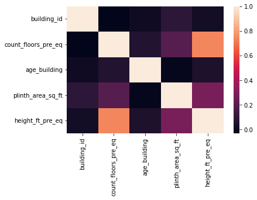

```python
# Create correlation matrix
correlation = df.select_dtypes("number").drop(columns="severe_damage").corr()
# Plot heatmap of `correlation`
sns.heatmap(correlation);
```

Only high value is related to `count_floors_pre_eq` and `height_ft_pre_eq` which makes sense

```python
df.info()
```

```
<class 'pandas.core.frame.DataFrame'>
Int64Index: 70836 entries, 164002 to 234835
Data columns (total 14 columns):
 #   Column                  Non-Null Count  Dtype
---  ------                  --------------  -----
 0   building_id             70836 non-null  int64
 1   count_floors_pre_eq     70836 non-null  int64
 2   age_building            70836 non-null  int64
 3   plinth_area_sq_ft       70836 non-null  int64
 4   height_ft_pre_eq        70836 non-null  int64
 5   land_surface_condition  70836 non-null  object
 6   foundation_type         70836 non-null  object
 7   roof_type               70836 non-null  object
 8   ground_floor_type       70836 non-null  object
 9   other_floor_type        70836 non-null  object
 10  position                70836 non-null  object
 11  plan_configuration      70836 non-null  object
 12  superstructure          70836 non-null  object
 13  severe_damage           70836 non-null  int64
dtypes: int64(6), object(8)
memory usage: 8.1+ MB
```

Always aiming to drop the column with the least predictive power. Investigation as follows:

```python
df["severe_damage"].corr(df["height_ft_pre_eq"]) , df["severe_damage"].corr(df["count_floors_pre_eq"])
```

```
(-0.0384765908330203, 0.002892630372575257)
```

Although negative, `height_ft_pre_eq` is a little bit more efficient than `count_floors_pre_eq` which will be dropped

```python
def wrangle(db_path):

    """
    Read SQLite data into a 'DataFrame'.

    Returns only treated information about buildings in Gorkha

    Parameters
    ----------
    db_path : str
        The path to the SQLite database
    """

    # Connect to database
    conn = sqlite3.connect(db_path)

    # Construct query
    query = """
        SELECT distinct(i.building_id) AS b_id,
           s.*,
           d.damage_grade
        FROM id_map AS i
        JOIN building_structure AS s ON i.building_id = s.building_id
        JOIN building_damage AS d ON i.building_id = d.building_id
        WHERE district_id = 4
    """

    # Read query results into DataFrame
    df = pd.read_sql(query, conn, index_col="b_id")

    # Select leaky columns
    drop_cols = [col for col in df.columns if "post_eq" in col]

    # Binary target column
    df['damage_grade'] = df['damage_grade'].str[-1].astype(int)
    df['severe_damage'] = (df['damage_grade'] > 3).astype(int)

    # Append leaky column
    drop_cols.append("damage_grade")

    # Drop multicolinearity column
    drop_cols.append("count_floors_pre_eq")

    # Drop columns
    df.drop(columns=drop_cols, inplace=True)

    return df
```

```python
df = wrangle("path/database.sqlite")
df.head()
```

| b_id | building_id | age_building | plinth_area_sq_ft | height_ft_pre_eq | land_surface_condition | foundation_type | roof_type | ground_floor_type | other_floor_type | position | plan_configuration | superstructure | severe_damage |
| --- | --- | --- | --- | --- | --- | --- | --- | --- | --- | --- | --- | --- | --- |
| 164002 | 164002 | 20 | 560 | 18 | Flat | Mud mortar-Stone/Brick | Bamboo/Timber-Light roof | Mud | TImber/Bamboo-Mud | Not attached | Rectangular | Stone, mud mortar | 0 |
| 164081 | 164081 | 21 | 200 | 12 | Flat | Mud mortar-Stone/Brick | Bamboo/Timber-Light roof | Mud | TImber/Bamboo-Mud | Not attached | Rectangular | Stone, mud mortar | 0 |
| 164089 | 164089 | 18 | 315 | 20 | Flat | Mud mortar-Stone/Brick | Bamboo/Timber-Light roof | Mud | TImber/Bamboo-Mud | Not attached | Rectangular | Stone, mud mortar | 0 |
| 164098 | 164098 | 45 | 290 | 13 | Flat | Mud mortar-Stone/Brick | Bamboo/Timber-Light roof | Mud | TImber/Bamboo-Mud | Not attached | Rectangular | Stone, mud mortar | 0 |
| 164103 | 164103 | 21 | 230 | 13 | Flat | Mud mortar-Stone/Brick | Bamboo/Timber-Light roof | Mud | TImber/Bamboo-Mud | Not attached | Rectangular | Stone, mud mortar | 0 |

Distributions of the `height_ft_pre_eq` column for both groups in the `severe_damage` column

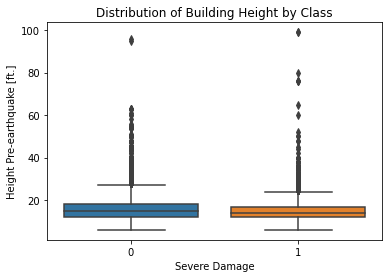

```python
# Create boxplot
sns.boxplot(x="severe_damage", y="height_ft_pre_eq", data=df)
# Update axis
plt.xlabel("Severe Damage")
plt.ylabel("Height Pre-earthquake [ft.]")
plt.title("Distribution of Building Height by Class");
```

Seems like the relation between height and damage is not so clear after all

Number of severed damaged buildings in a plot

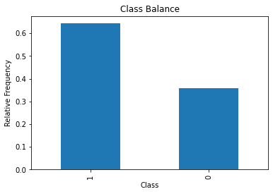

```python
# Plot value counts of "severe_damage"
df["severe_damage"].value_counts(normalize=True).plot(
    kind="bar", xlabel="Class", ylabel="Relative Frequency", title="Class Balance"
);
```

The foundation type might be another column that could lead to interesting findings

```python
df["foundation_type"].unique()
```

```
array(['Mud mortar-Stone/Brick', 'RC', 'Cement-Stone/Brick',
       'Bamboo/Timber', 'Other'], dtype=object)
```

```python
# Create pivot table of foundation type and severe damage
foundation_pivot = pd.pivot_table(
    df, index="foundation_type", values="severe_damage", aggfunc=np.mean
).sort_values(by="severe_damage")
foundation_pivot
```

| foundation_type | severe_damage |
| --- | --- |
| RC | 0.026224 |
| Bamboo/Timber | 0.324074 |
| Cement-Stone/Brick | 0.421908 |
| Mud mortar-Stone/Brick | 0.687792 |
| Other | 0.818898 |

Seems like the foundation type does hold some interesting information. I will be now investigating which types of foundations lead to a less significant damage and the ones which lead to a more severe damage

```python
majority_class_prop, minority_class_prop = df["severe_damage"].value_counts(normalize=True)
majority_class_prop, minority_class_prop
```

```
(0.6425969845841097, 0.3574030154158902)
```

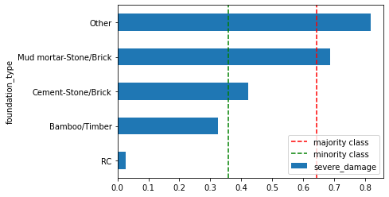

```python
# Plot bar chart of `foundation_pivot`
foundation_pivot.plot(kind="barh", legend=None)
plt.axvline(
    majority_class_prop, linestyle='--', color='red', label='majority class'
)
plt.axvline(
    minority_class_prop, linestyle='--', color='green', label='minority class'
)
plt.legend(loc="lower right");
```

The plot helps me verify that there is indeed a relation between damage and the foundation type

Checking for high and low cardinality categorical features

```python
df.head()
```

| b_id | building_id | age_building | plinth_area_sq_ft | height_ft_pre_eq | land_surface_condition | foundation_type | roof_type | ground_floor_type | other_floor_type | position | plan_configuration | superstructure | severe_damage |
| --- | --- | --- | --- | --- | --- | --- | --- | --- | --- | --- | --- | --- | --- |
| 164002 | 164002 | 20 | 560 | 18 | Flat | Mud mortar-Stone/Brick | Bamboo/Timber-Light roof | Mud | TImber/Bamboo-Mud | Not attached | Rectangular | Stone, mud mortar | 0 |
| 164081 | 164081 | 21 | 200 | 12 | Flat | Mud mortar-Stone/Brick | Bamboo/Timber-Light roof | Mud | TImber/Bamboo-Mud | Not attached | Rectangular | Stone, mud mortar | 0 |
| 164089 | 164089 | 18 | 315 | 20 | Flat | Mud mortar-Stone/Brick | Bamboo/Timber-Light roof | Mud | TImber/Bamboo-Mud | Not attached | Rectangular | Stone, mud mortar | 0 |
| 164098 | 164098 | 45 | 290 | 13 | Flat | Mud mortar-Stone/Brick | Bamboo/Timber-Light roof | Mud | TImber/Bamboo-Mud | Not attached | Rectangular | Stone, mud mortar | 0 |
| 164103 | 164103 | 21 | 230 | 13 | Flat | Mud mortar-Stone/Brick | Bamboo/Timber-Light roof | Mud | TImber/Bamboo-Mud | Not attached | Rectangular | Stone, mud mortar | 0 |

```python
# Check for high- and low-cardinality categorical features
df.select_dtypes("object").nunique()
```

```
land_surface_condition     3
foundation_type            5
roof_type                  3
ground_floor_type          5
other_floor_type           4
position                   4
plan_configuration        10
superstructure            11
dtype: int64
```

```python
df.building_id.count(), len(df)
```

```
(70836, 70836)
```

Seems like there is no column that stands out when the type is `object`. However there is the `building_id` column which is of type `int`

```python
def wrangle(db_path):

    """
    Read SQLite data into a 'DataFrame'.

    Returns only treated information about buildings in Gorkha

    Parameters
    ----------
    db_path : str
        The path to the SQLite database
    """

    # Connect to database
    conn = sqlite3.connect(db_path)

    # Construct query
    query = """
        SELECT distinct(i.building_id) AS b_id,
           s.*,
           d.damage_grade
        FROM id_map AS i
        JOIN building_structure AS s ON i.building_id = s.building_id
        JOIN building_damage AS d ON i.building_id = d.building_id
        WHERE district_id = 4
    """

    # Read query results into DataFrame
    df = pd.read_sql(query, conn, index_col="b_id")

    # Select leaky columns
    drop_cols = [col for col in df.columns if "post_eq" in col]

    # Binary target column
    df['damage_grade'] = df['damage_grade'].str[-1].astype(int)
    df['severe_damage'] = (df['damage_grade'] > 3).astype(int)

    # Append leaky column
    drop_cols.append("damage_grade")

    # Drop multicolinearity column
    drop_cols.append("count_floors_pre_eq")

    # Drop high-cordinanilty columns
    drop_cols.append("building_id")

    # Drop columns
    df.drop(columns=drop_cols, inplace=True)

    return df
```

```python
df = wrangle("path/database.sqlite")
df.head()
```

| b_id | age_building | plinth_area_sq_ft | height_ft_pre_eq | land_surface_condition | foundation_type | roof_type | ground_floor_type | other_floor_type | position | plan_configuration | superstructure | severe_damage |
| --- | --- | --- | --- | --- | --- | --- | --- | --- | --- | --- | --- | --- |
| 164002 | 20 | 560 | 18 | Flat | Mud mortar-Stone/Brick | Bamboo/Timber-Light roof | Mud | TImber/Bamboo-Mud | Not attached | Rectangular | Stone, mud mortar | 0 |
| 164081 | 21 | 200 | 12 | Flat | Mud mortar-Stone/Brick | Bamboo/Timber-Light roof | Mud | TImber/Bamboo-Mud | Not attached | Rectangular | Stone, mud mortar | 0 |
| 164089 | 18 | 315 | 20 | Flat | Mud mortar-Stone/Brick | Bamboo/Timber-Light roof | Mud | TImber/Bamboo-Mud | Not attached | Rectangular | Stone, mud mortar | 0 |
| 164098 | 45 | 290 | 13 | Flat | Mud mortar-Stone/Brick | Bamboo/Timber-Light roof | Mud | TImber/Bamboo-Mud | Not attached | Rectangular | Stone, mud mortar | 0 |
| 164103 | 21 | 230 | 13 | Flat | Mud mortar-Stone/Brick | Bamboo/Timber-Light roof | Mud | TImber/Bamboo-Mud | Not attached | Rectangular | Stone, mud mortar | 0 |

# Split

Creating the feature matrix `X` and target vector `y`

```python
target = "severe_damage"
X = df.drop(columns=target)
y = df[target]
```

Dividing the data (`X` and `y`) into training and test sets using a randomized train-test split. Will be setting test as 20% of total data

```python
X_train, X_test, y_train, y_test = train_test_split(
    X, y, test_size=0.2, random_state=42
)
```

Dividing the training data (X_train and y_train) into training and validation sets using a randomized train-test split. The validation data will be set to 20% of the remaining data

```python
X_train, X_val, y_train, y_val = train_test_split(
    X_train, y_train, test_size=0.2, random_state=42
)
```

# Building the Model

## Baseline

The baseline will be based on the approach of assigning severe damage to all buildings since the majority of buildings were damaged

```python
acc_baseline = y_train.value_counts(normalize=True).max()
print("Baseline Accuracy:", round(acc_baseline, 2))
```

```
Baseline Accuracy: 0.64
```

`OrdinalEncoder` will be ideal for the `DecisionTreeClassifier` model

```python
# Build Model
model = make_pipeline(
    OrdinalEncoder(), DecisionTreeClassifier(random_state=42)
)
# Fit model to training data
model.fit(X_train, y_train)
```

```
Pipeline(steps=[('ordinalencoder',
                 OrdinalEncoder(cols=['land_surface_condition',
                                      'foundation_type', 'roof_type',
                                      'ground_floor_type', 'other_floor_type',
                                      'position', 'plan_configuration',
                                      'superstructure'],
                                mapping=[{'col': 'land_surface_condition',
                                          'data_type': dtype('O'),
                                          'mapping': Flat              1
Moderate slope    2
Steep slope       3
NaN              -2
dtype: int64},
                                         {'col': 'foundation_type',
                                          'dat...
E-shape                             7
H-shape                             8
Others                              9
Building with Central Courtyard    10
NaN                                -2
dtype: int64},
                                         {'col': 'superstructure',
                                          'data_type': dtype('O'),
                                          'mapping': Stone, mud mortar        1
Stone                    2
RC, engineered           3
Brick, cement mortar     4
Adobe/mud                5
Timber                   6
RC, non-engineered       7
Brick, mud mortar        8
Stone, cement mortar     9
Bamboo                  10
Other                   11
NaN                     -2
dtype: int64}])),
                ('decisiontreeclassifier',
                 DecisionTreeClassifier(random_state=42))])
```

## First evaluation

```python
acc_train = accuracy_score(y_train, model.predict(X_train))
acc_val = model.score(X_val, y_val)

print("Training Accuracy:", round(acc_train, 2))
print("Validation Accuracy:", round(acc_val, 2))
```

```
Training Accuracy: 0.98
Validation Accuracy: 0.65
```

Using the `get_depth` method on the `DecisionTreeClassifier` in the model to see how deep the tree grew during training

```python
tree_depth = model.named_steps["decisiontreeclassifier"].get_depth()
print("Tree Depth:", tree_depth)
```

```
Tree Depth: 49
```

## Iterating

Training a model for every `max_depth` in `depth_hyperparams`. Every time a new model is trained, the code will also calculate the training and validation accuracy scores and append them to the `training_acc` and `validation_acc` lists, respectively.

```python
# Creating a range of possible values for max_depth hyperparameter of the model's DecisionTreeClassifier
depth_hyperparams = range(1, 50, 2)

# Create empty lists for training and validation accuracy scores
training_acc = []
validation_acc = []

for d in depth_hyperparams:
    # Create model with `max_depth` of `d`
    test_model = make_pipeline(
        OrdinalEncoder(),
        DecisionTreeClassifier(max_depth=d, random_state=42)
    )
    # Fit model to training data
    test_model.fit(X_train, y_train)
    # Calculate training accuracy score and append to `training_acc`
    training_acc.append(test_model.score(X_train, y_train))
    # Calculate validation accuracy score and append to `training_acc`
    validation_acc.append(test_model.score(X_val, y_val))

print("Training Accuracy Scores:", training_acc[:3])
print("Validation Accuracy Scores:", validation_acc[:3])
```

```
Training Accuracy Scores: [0.7071072484228174, 0.7117395332421582, 0.7162394670666608]
Validation Accuracy Scores: [0.7088406564319746, 0.7132521616375508, 0.7166049055937886]
```

To help identify the best model a plot will be in handy. With two lines, the first line will plot the `training_acc` values as a function of `depth_hyperparams`, and the second will plot `validation_acc` as a function of `depth_hyperparams`

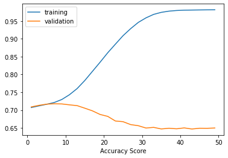

```python
plt.plot(depth_hyperparams, training_acc, label="training")
plt.plot(depth_hyperparams, validation_acc, label="validation")
plt.xlabel("Max Depth")
plt.xlabel("Accuracy Score")
plt.legend();
```

According to the plot, the optimum `max_depth` value is around 7 or 8, I will be choosing 7

```python
# Build Model
model = make_pipeline(
    OrdinalEncoder(), DecisionTreeClassifier(max_depth=7, random_state=42)
)
# Fit model to training data
model.fit(X_train, y_train)
acc_train = accuracy_score(y_train, model.predict(X_train))
acc_val = model.score(X_val, y_val)

print("Training Accuracy:", round(acc_train, 2))
print("Validation Accuracy:", round(acc_val, 2))
```

```
Training Accuracy: 0.72
Validation Accuracy: 0.72
```

# Communicating the Results

A plot to help visualize the decision logic of the model is ideal for communicating the results of a decision tree model

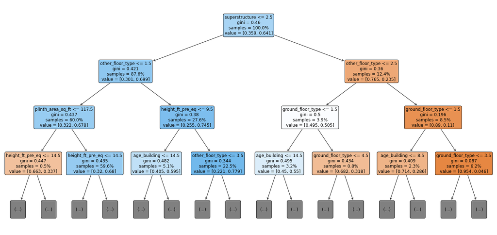

```python
# Create larger figure
fig, ax = plt.subplots(figsize=(25, 12))
# Plot tree
plot_tree(
    decision_tree=model.named_steps["decisiontreeclassifier"],
    feature_names=X_train.columns,
    filled=True,  # Color leaf with class
    rounded=True,  # Round leaf edges
    proportion=True,  # Display proportion of classes in leaf
    max_depth=3,  # Only display first 3 levels
    fontsize=12,  # Enlarge font
    ax=ax,  # Place in figure axis
);
```

Now that the model is ready I will be able to see which features had the most impact

```python
# Getting the features and their respective importances
features = X_train.columns
importances = model.named_steps["decisiontreeclassifier"].feature_importances_
feat_imp = pd.Series(importances, index=features)
```

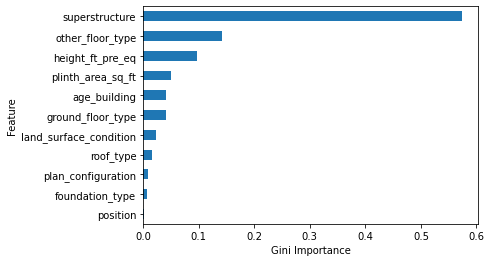

```python
# Create horizontal bar chart
feat_imp.sort_values().plot(kind="barh")
plt.xlabel("Gini Importance")
plt.ylabel("Feature");
```